# analysis_and_model

## Home Depot Product Search Relevance Model

Shoppers rely on Home Depot’s product authority to find and buy the latest products and to get timely solutions to their home improvement needs. From installing a new ceiling fan to remodeling an entire kitchen, with the click of a mouse or tap of the screen, customers expect the correct results to their queries – quickly. Speed, accuracy and delivering a frictionless customer experience are essential.

In this project, I will help improve their customers' shopping experience by developing a model that can predict the relevance of search results relatively well.

Search relevancy is an implicit measure Home Depot uses to gauge how quickly they can get customers to the right products. Currently, human raters evaluate the impact of potential changes to their search algorithms, which is a slow and subjective process. By removing or minimizing human input in search relevance evaluation, Home Depot hopes to increase the number of iterations their team can perform on the current search algorithms.

### 0. Import Basic Libraries

```python
import pandas as pd
import numpy as np
import seaborn as sns
#from sklearn.feature_extraction.txt import CountVectorizer, TfidfTransformer, TfidfVectorizer
import warnings
warnings.filterwarnings('ignore')
import matplotlib.pyplot as plt
%matplotlib inline
```

### 1. General Data Overview and EDA

First, I import and analyze the overall training and testing data set to assess the fields contained. In addition, I will conduct an exploratory data analysis on the products by different attributes to understand their distribution.

```python
train = pd.read_csv('train.csv',encoding='latin1')
test = pd.read_csv('test.csv',encoding='latin1')
prod_desc = pd.read_csv('product_descriptions.csv',encoding='latin1')
```

Let's get a brief overview of the first few rows of the train table.

```python
train.head()
```

|  | id | product_uid | product_title | search_term | relevance |
| --- | --- | --- | --- | --- | --- |
| 0 | 2 | 100001 | Simpson Strong-Tie 12-Gauge Angle | angle bracket | 3.00 |
| 1 | 3 | 100001 | Simpson Strong-Tie 12-Gauge Angle | l bracket | 2.50 |
| 2 | 9 | 100002 | BEHR Premium Textured DeckOver 1-gal. #SC-141 ... | deck over | 3.00 |
| 3 | 16 | 100005 | Delta Vero 1-Handle Shower Only Faucet Trim Ki... | rain shower head | 2.33 |
| 4 | 17 | 100005 | Delta Vero 1-Handle Shower Only Faucet Trim Ki... | shower only faucet | 2.67 |

```python
train.shape
```

```
(74067, 5)
```

As we can see above, the training table have 5 columns with 74067 entries. Next, let's group the products by uid (unique ids) to get a sense of the total number of different products.

```python
uids = train.groupby('product_uid').count()
uids.shape[0]
```

```
54667
```

As we can see, there are a total of 54667 unique proudcts among the 74067 search terms. Next, I will rank the products by the frequency of their search appearance to see what products are among the most popular.

```python
sorted_uids = uids[['id']].sort_values('id', ascending = False)
sorted_uids.columns = ['count']
sorted_uids.head(10)
```

| product_uid | count |
| --- | --- |
| 102893 | 21 |
| 101959 | 21 |
| 101892 | 18 |
| 102456 | 17 |
| 101539 | 17 |
| 104691 | 17 |
| 103763 | 15 |
| 101442 | 14 |
| 107728 | 14 |
| 120606 | 14 |

As shown below, we can see that at least over 98% of the number of search appearances are between 1 and 7 times. The higher number of search appearances are the outliers in this distribution. However, the sheer number of these more frequent searches makes it easier for me to individually track down and investigate each item to find out its significance to the users.

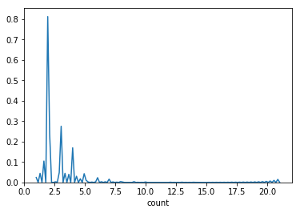

```python
sns.distplot(sorted_uids['count'], hist = False);
```

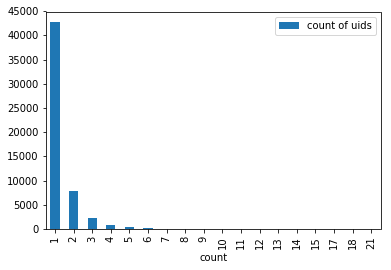

```python
sorted_uids['uid'] = sorted_uids.index
sorted_uids.columns = ['count','count of uids']
sorted_uids.groupby('count').count().plot.bar();
```

```python
sorted_uid_count = sorted_uids.groupby('count').count()
sorted_uid_count
```

| count | count of uids |
| --- | --- |
| 1 | 42765 |
| 2 | 7824 |
| 3 | 2385 |
| 4 | 909 |
| 5 | 386 |
| 6 | 190 |
| 7 | 95 |
| 8 | 45 |
| 9 | 27 |
| 10 | 13 |
| 11 | 4 |
| 12 | 4 |
| 13 | 5 |
| 14 | 8 |
| 15 | 1 |
| 17 | 3 |
| 18 | 1 |
| 21 | 2 |

As expected above, the distribution of number of search appearances is unimodal and highly skewed to the right. I will zoom in on the ones with the higher search appearances and look for any anomaly. Let's look at the items that are searched at least 10 times.

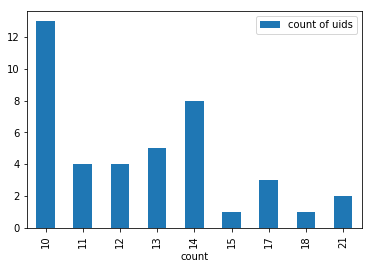

```python
sorted_uid_count.iloc[9:].plot.bar();
```

It's interesting to see in the above graph that the distribution of number of search appearances of uids does not decrease monotonically. The frequency of number of search appearances increases from 11 to 14 and then drop significantly at 15. Let's take a closer look at the items with 14 and 15 searches.

```python
four_fifteen_searches = sorted_uids[(sorted_uids['count']==14) | (sorted_uids['count']==15)][['count']]
train[train['product_uid'].isin(four_fifteen_searches.index)].groupby('product_title').count()
```

| product_title | id | product_uid | search_term | relevance |
| --- | --- | --- | --- | --- |
| 23/32 in. x 4 ft. x 8 ft. RTD Sheathing Syp | 14 | 14 | 14 | 14 |
| 36 in. x 80 in. 6-Panel Primed Premium Steel Front Door Slab | 14 | 14 | 14 | 14 |
| Oriented Strand Board (Common: 7/16 in. x 4 ft. x 8 ft.; Actual: 0.418 in. x 47.75 in. x 95.75 in.) | 14 | 14 | 14 | 14 |
| Owens Corning R-30 Unfaced Insulation Continuous Roll 15 in. x 25 ft. | 14 | 14 | 14 | 14 |
| Ryobi 18-Volt ONE+ High Capacity LITHIUM+ Battery (2-Pack) | 14 | 14 | 14 | 14 |
| Ryobi ONE+ 18-Volt Lithium-Ion Cordless Super Combo Kit (4-Piece) | 14 | 14 | 14 | 14 |
| WeatherShield 2 in. x 4 in. x 8 ft. #2 Prime Prime Pressure-Treated Lumber | 14 | 14 | 14 | 14 |
| Whirlpool 1.7 cu. ft. Over the Range Microwave in Stainless Steel | 14 | 14 | 14 | 14 |
| Whirlpool Gold Series Top Control Dishwasher in Monochromatic Stainless Steel with Silverware Spray | 15 | 15 | 15 | 15 |

Let's now connect the product_uids of these items with the product description table.

```python
prod_desc[prod_desc['product_uid'].isin(four_fifteen_searches.index)][['product_description']]
```

|  | product_description |
| --- | --- |
| 408 | Every piece meets the highest grading standard... |
| 1311 | JELD-WEN Premium Steel doors offer that relied... |
| 1441 | Easily match the amount of ventilation you nee... |
| 2161 | OSB is a material with high mechanical propert... |
| 2233 | EcoTouch insulation is the reinvention of fibe... |
| 3762 | Leave the cleaning decisions to this Whirlpool... |
| 7727 | Plywood sheathing is ideal for residential and... |
| 9593 | Ryobi 18-Volt ONE+ introduces lithium-ion perf... |
| 20605 | Purchase this 2-Pack of Ryobi 18-Volt ONE+ lit... |

### 2. Exploring and Evaluating Correlation

In the next part, I will try to evaluate the correlation between the relevance of the product and the attribute of the product. This will in turn gives me insight into what to focus on when developing the model. First, I will start by looking at the general distribution of the relevance of different products. To remind myself, the rating of relevance is on a scale of 3 (with 1 being the least relevant, and 3 being the most relevant).

To begin the investigation, I hypothesize that there is a correlation between the number of search appearances for a product and the relevance of searches.

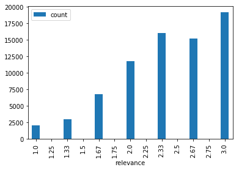

```python
relevance = train.groupby('relevance').count()[['id']]
relevance.columns = ['count']
relevance[['count']].plot.bar();
```

```python
train['relevance'].value_counts()
```

```
3.00    19125
2.33    16060
2.67    15202
2.00    11730
1.67     6780
1.33     3006
1.00     2105
2.50       19
2.25       11
2.75       11
1.75        9
1.50        5
1.25        4
Name: relevance, dtype: int64
```

As we can see in general, the higher the relevance of the product search is, the more searches there are. Interestingly, the relevance is gapped by a 0.33 difference (there are few relevance ratings such as 1.25, 1.5, 1.75, etc.)

Instantly, we can see that the relevance of the searches isn't directly correlated with the number of search appearances. While the number of the searches by relevance increases, the number of the searches by search appearances decreases. To verify this, let's visualize the relationship between the two.

```python
rating = [list(train[train['product_uid'] == uid]['relevance'])[0] for uid in uids.index]
```

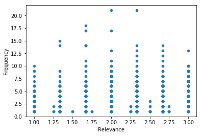

```python
relevance_freq = pd.DataFrame({'Frequency':uids['id'], 'Relevance':rating})
relevance_freq.plot.scatter('Relevance','Frequency');
```

As we can see above, there is no clear trend that indicates any correlation between the relevance of the search results and the frequency of the searches (search appearances) for a product.

Now that my first hypothesize is disproved, it is apparent that I should focus my efforst on the product description (which requires some text analysis and processing). To remind myself of the product description table, let's look at the first few rows and a few other attributes of the descriptions.

```python
prod_desc.head()
```

|  | product_uid | product_description |
| --- | --- | --- |
| 0 | 100001 | Not only do angles make joints stronger, they ... |
| 1 | 100002 | BEHR Premium Textured DECKOVER is an innovativ... |
| 2 | 100003 | Classic architecture meets contemporary design... |
| 3 | 100004 | The Grape Solar 265-Watt Polycrystalline PV So... |
| 4 | 100005 | Update your bathroom with the Delta Vero Singl... |

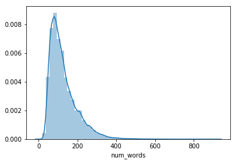

```python
prod_desc['num_words'] = prod_desc['product_description'].str.split(' ').apply(len)
sns.distplot(prod_desc['num_words']);
```

```python
sum(list(prod_desc['num_words']))/prod_desc.shape[0]
```

```
127.14138296846369
```

As shown above, the distribution of the number of words in the description for an item is unimodal and right skewed. The average length of a description is about 127 words. Next, I'm going to take a brief look at the frequency of the words used in all the descriptions using a word cloud.

```python
prod_desc.columns
```

```
Index(['product_uid', 'product_description', 'num_words'], dtype='object')
```

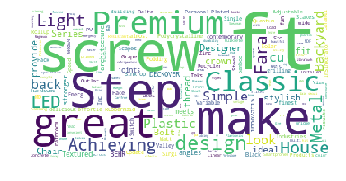

```python
from wordcloud import WordCloud, STOPWORDS
stopwords = set(STOPWORDS)
wordcloud = WordCloud(
                          background_color='white',
                          stopwords=stopwords,
                          max_words=200,
                          max_font_size=100,
                          random_state=42
                         ).generate(str(prod_desc['product_description']))

plt.imshow(wordcloud)
plt.axis('off')
plt.show()
```

As we can see above, some of the most common PRODUCT-RELATED words used in the description are Screw, Step, Premium, ft, Light, thread, design, Metal, Plastic. I will take a step further and generate a word cloud for those items that are searched up more frequently (>=10 times).

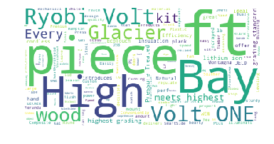

```python
at_least_ten = sorted_uids[sorted_uids['count'] >= 10]
wordcloud = WordCloud(
                          background_color='white',
                          stopwords=stopwords,
                          max_words=200,
                          max_font_size=100,
                          random_state=42
                         ).generate(str(prod_desc[prod_desc['product_uid'].isin(at_least_ten.index)]['product_description']))

plt.imshow(wordcloud)
plt.axis('off')
plt.show()
```

As we can see, some of the most common PRODUCT-RELATED description words for frequently searched products are piece, High, Bay, ft, Volt ONE, Ryobi Volt, Glacier, etc. With a bit of search and reading throught the descriptions, the focus on Volt suggests the relative popularity of batteries.

### 3. Data Cleaning and Preparation

Now that I have a better understanding the text data for the products, it is time to clean, reformat, and prepare the data for constructing the model used to predict the relevance of the search results (the goal of this analysis)

First, for the convenience of working on different columns at the same time, I will join multiple tables (the training table and the product description) together.

```python
df_all = pd.concat((train,test),axis = 0, ignore_index = True)
df_all = pd.merge(df_all,prod_desc,how='left',on='product_uid')
```

```python
df_all.head(5)
```

|  | id | product_title | product_uid | relevance | search_term | product_description | num_words |
| --- | --- | --- | --- | --- | --- | --- | --- |
| 0 | 2 | Simpson Strong-Tie 12-Gauge Angle | 100001 | 3.00 | angle bracket | Not only do angles make joints stronger, they ... | 129 |
| 1 | 3 | Simpson Strong-Tie 12-Gauge Angle | 100001 | 2.50 | l bracket | Not only do angles make joints stronger, they ... | 129 |
| 2 | 9 | BEHR Premium Textured DeckOver 1-gal. #SC-141 ... | 100002 | 3.00 | deck over | BEHR Premium Textured DECKOVER is an innovativ... | 168 |
| 3 | 16 | Delta Vero 1-Handle Shower Only Faucet Trim Ki... | 100005 | 2.33 | rain shower head | Update your bathroom with the Delta Vero Singl... | 104 |
| 4 | 17 | Delta Vero 1-Handle Shower Only Faucet Trim Ki... | 100005 | 2.67 | shower only faucet | Update your bathroom with the Delta Vero Singl... | 104 |

Now, with all the data I need in hand, it is time to process and simplify the text input (descriptions) to prepare it for the modeling stage.

Let me define two helper functions that will be used to pre-process the description input.

```python
from nltk.stem.snowball import SnowballStemmer
from nltk.tokenize import word_tokenize
```

```python
stemmer = SnowballStemmer('english')
```

The function string_stemmer below helps reduce a word to its simplest form, meaning that it removes any tense, plural form, essentially all morphological affixes from words, leaving only the word stem. By having the simplest word, I can increase the frequency of a single word in the description (now indistinguishable without the affixes) and improve the modeling accuracy.

```python
def string_stemmer(string):
    return ' '.join([stemmer.stem(word) for word in string.lower().split()])
```

The function common_word below searches for the number of common words in string1 from string2. It will help me determine the frequency of words.

```python
def common_word(string1, string2):
    return sum([int(string2.find(word)>=0) for word in string1.split()])
```

Now, apply the stemming method to all the text columns in the DataFrame:

```python
for column in ['search_term','product_title','product_description']:
    df_all[column]=df_all[column].apply(string_stemmer)
```

Next, through a series of operations. I will add a few new columns to the DataFrame: the length of the search query, product information (which is esstenailly the combination of the search term, product title, and product description), the number of common words in product title, and the number of common words in product description.

```python
df_all['length_of_query'] = df_all['search_term'].map(lambda x: len(x.split())).astype(np.int64)
df_all['product_info'] = df_all['search_term']+'\t'+df_all['product_title']+'\t'+df_all['product_description']
df_all['word_in_title'] = df_all['product_info'].map(lambda x: common_word(x.split('\t')[0],x.split('\t')[1]))
df_all['word_in_description'] = df_all['product_info'].map(lambda x: common_word(x.split('\t')[0],x.split('\t')[2]))
df_all = df_all.drop(['search_term','product_title','product_description','product_info'],axis=1)
```

Lastly, let's resplit the df_all DataFrame back into the training data set and the testing data set.

```python
df_train = df_all.iloc[:num_train]
df_test = df_all.iloc[num_train:]
id_test = df_test['id']
```

### 4. Applying and Evaluating Model

Finally, with all the data prepared, I can apply the model to predict the search relevance of the products. I will be using the ensemble method: Random Forest (combining multiple decision trees) method to create the model. This can also help reduce the variance that can occur from a single decision tree.

```python
y_train = df_train['relevance'].values
X_train = df_train.drop(['id','relevance'],axis=1).values
X_test = df_test.drop(['id','relevance'],axis=1).values
```

```python
rf = RandomForestRegressor(n_estimators = 15, max_depth = 6, random_state = 0)
clf = BaggingRegressor(rf, n_estimators = 45, max_samples = 0.1, random_state = 25)
clf.fit(X_train, y_train)
y_pred = clf.predict(X_train)
```

```python
y_train
```

```
array([ 3.  ,  2.5 ,  3.  , ...,  2.33,  3.  ,  2.33])
```

```python
y_pred
```

```
array([ 2.43466815,  2.43466815,  2.43726239, ...,  2.02620297,
        2.08993729,  2.28957603])
```

Now, I will evaluate the error of my model using the training data set.

```python
rmse = np.sqrt(np.mean(y_train-y_pred)**2)
print('The Root Mean Square Error is: ' + str(rmse))
```

```
The Root Mean Square Error is: 0.000102246514715
```

```python
score_with_index = [[y_train[i], i] for i in range(len(y_train))]
most_relevant = [score_with_index[i] for i in range(len(score_with_index)) if score_with_index[i][0] == 3.0]
indexes_most_relevant = [item[1] for item in most_relevant]
pred_most_relevant = [y_pred[i] for i in indexes_most_relevant]
original_most_relevant = [item[0] for item in most_relevant]
```

```python
pd.DataFrame({'Original':original_most_relevant, 'Predictied':pred_most_relevant}).head()
```

|  | Original | Predictied |
| --- | --- | --- |
| 0 | 3.0 | 2.434668 |
| 1 | 3.0 | 2.437262 |
| 2 | 3.0 | 2.447121 |
| 3 | 3.0 | 2.433351 |
| 4 | 3.0 | 2.634071 |

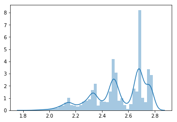

```python
sns.distplot(pred_most_relevant)
```

Lastly, generate the test predictions:

```python
result = pd.DataFrame({'id':id_test,'pred_relevance':clf.predict(X_test)})
```